# route

Use `cy.route()` to manage the behavior of network requests.

> ⚠️ **`cy.server()` and `cy.route()` are deprecated in Cypress 6.0.0**. In a future release, support for `cy.server()` and `cy.route()` will be removed. Consider using `cy.intercept()` instead. See our guide on [Migrating `cy.route()` to `cy.intercept()`](https://docs.cypress.io/guides/references/migration-guide#Migrating-cy-route-to-cy-intercept)

> ⚠️ `cy.route()` and `cy.server()` only support intercepting XMLHttpRequests. Requests using the Fetch API and other types of network requests like page loads and `<script>` tags will not be intercepted by `cy.route()` and `cy.server()`.

> **To support requests using the Fetch API you can use one of the solutions below:**
> - Use `cy.intercept()` which supports requests using the Fetch API and other types of network requests like page loads. See `cy.intercept()`.
> - Polyfill `window.fetch` to spy on and stub requests using `cy.route()` and `cy.server()` by enabling [`experimentalFetchPolyfill`](https://on.cypress.io/experimental). See [#95](https://github.com/cypress-io/cypress/issues/95) for more details and temporary workarounds.

## Syntax

```javascript
cy.route(url)
cy.route(url, response)
cy.route(method, url)
cy.route(method, url, response)
cy.route(callbackFn)
cy.route(options)
```

### Usage

**Correct Usage**

```javascript
cy.route('/users/**')
```

### Arguments

**url** *(String, Glob, RegExp)*

Listen for a route matching the specific URL.

**response** *(String, Object, Array)*

Supply a response `body` to *stub* in the matching route.

**method** *(String)*

Match the route to a specific method (`GET`, `POST`, `PUT`, etc).

> If no method is defined Cypress will match `GET` requests by default.

**callbackFn** *(Function)*

Listen for a route matching a returned object literal from a callback function. Functions that return a `Promise` will automatically be awaited.

**options** *(Object)*

Pass in an options object to change the default behavior of `cy.route()`. By default `cy.route()` inherits its options from `cy.server()`.

| Option | Default | Description |
| --- | --- | --- |
| `delay` | `0` | Delay for stubbed responses (in ms) |
| `force404` | `false` | Forcibly send a 404 status when the XHR does not match any existing `cy.route()`. |
| `headers` | `null` | Response headers for stubbed routes |
| `method` | `GET` | Method to match against requests |
| `onAbort` | `null` | Callback function which fires anytime an XHR is aborted |
| `onRequest` | `null` | Callback function when a request is sent |
| `onResponse` | `null` | Callback function when a response is returned |
| `response` | `null` | Response body when stubbing routes |
| `status` | `200` | Response status code when stubbing routes |
| `url` | `null` | String or RegExp url to match against request urls |

You can also set options for all `cy.wait()`'s `requestTimeout` and `responseTimeout` globally in configuration to control how long to wait for the request and response of a supplied route.

### Yields

- `cy.route()` yields `null` .
- `cy.route()` can be aliased, but otherwise cannot be chained further.

## Examples

### Without Stubbing

If you do not pass a `response` to a route, Cypress will pass the request through without stubbing it. We can still wait for the request to resolve later.

#### Wait on XHR `GET` request matching `url`

```javascript
cy.server()
cy.route('**/users').as('getUsers')
cy.visit('/users')
cy.wait('@getUsers')
```

#### Wait on XHR's matching `method` and `url`

```javascript
cy.server()
cy.route('POST', '**/users').as('postUser')
cy.visit('/users')
cy.get('#first-name').type('Julius{enter}')
cy.wait('@postUser')
```

#### Setup route to `POST` to login

> [Check out our example recipe using `cy.route()` to POST for login in HTML web forms](https://docs.cypress.io/examples/examples/recipes#Logging-In)

#### Wait on `url` matching glob

Under the hood Cypress uses minimatch to match glob patterns of `url`.

This means you can take advantage of `*` and `**` glob support. This makes it *much* easier to route against dynamic segments without having to build up a complex `RegExp`.

We expose `Cypress.minimatch` as a function that you can use in your console to test routes.

#### Match route against any UserId

```javascript
cy.server()
cy.route('**/users/*/comments')

// https://localhost:7777/users/123/comments     <-- matches
// https://localhost:7777/users/123/comments/465 <-- does not match
```

#### Use glob to match all segments

```javascript
cy.server()
cy.route('**/posts/**')

// https://localhost:7777/posts/1            <-- matches
// https://localhost:7777/posts/foo/bar/baz  <-- matches
// https://localhost:7777/posts/quuz?a=b&1=2 <-- matches
```

#### Override `url` glob matching options

When we check `glob` patterns with minimatch, by default Cypress uses sets `matchBase` to `true`. You can override this option in `cy.server()` options.

If you want to permanently override these options you could do so by setting `Cypress.Server.defaults()`.

```javascript
cy.server({
  urlMatchingOptions: { matchBase: false, dot: true }
})
cy.route(...)
```

### With Stubbing

If you pass a `response` to `cy.route()`, Cypress will stub the response in the request.

#### `url` as a string

When passing a `string` as the `url`, the XHR's URL must match *exactly* what you've written. You'll want to use the decoded string and not include any hash encoding (ie. use `@` instead of `%40`).

```javascript
cy.server()
cy.route('https://localhost:7777/surveys/customer?email=john@doe.com', [
  {
    id: 1,
    name: 'john',
  },
])
```

#### `url` as a RegExp

When passing a RegExp as the `url`, the XHR's url will be tested against the regular expression and will apply if it passes.

```javascript
cy.server()
cy.route(/users\/\d+/, { id: 1, name: 'Phoebe' })
```

```javascript
// Application Code
$.get('https://localhost:7777/users/1337', (data) => {
  console.log(data) // => {id: 1, name: "Phoebe"}
})
```

#### Response functions

You can also use a function as a response which enables you to add logic surrounding the response.

Functions that return a `Promise` will automatically be awaited.

```javascript
const commentsResponse = (routeData) => {
  //routeData is a reference to the current route's information
  return {
    data: someOtherFunction(routeData),
  }
}

cy.route('POST', '**/comments', commentsResponse)
```

#### Matching requests and routes

Any request that matches the `method` and `url` of a route will be responded to based on the configuration of that route.

> `GET` is the default HTTP method used to match routes. If you want to stub a route with another HTTP method such as `POST` then you must be explicit about the method.

> If a request doesn't match any route then the behavior depends on the value of the `force404` option on the `cy.server()`:
> - if `force404` is `false` (the default) then the request will [pass through to the server](https://docs.cypress.io/guides/guides/network-requests#Use-Server-Responses).
> - if `force404` is `true` then the response will be a 404.

> You can read more about this behavior here.

#### Specify the method

The below example matches all `DELETE` requests to "/users" and stubs a response with an empty JSON object.

```javascript
cy.server()
cy.route('DELETE', '**/users/*', {})
```

#### Making multiple requests to the same route

You can test a route multiple times with unique response objects by using [aliases](https://docs.cypress.io/guides/core-concepts/variables-and-aliases#Aliases) and cy.wait(). Each time we use `cy.wait()` for an alias, Cypress waits for the next nth matching request.

```javascript
cy.server()
cy.route('/beetles', []).as('getBeetles')
cy.get('#search').type('Weevil')

// wait for the first response to finish
cy.wait('@getBeetles')

// the results should be empty because we
// responded with an empty array first
cy.get('#beetle-results').should('be.empty')

// now re-define the /beetles response
cy.route('/beetles', [{ name: 'Geotrupidae' }])

cy.get('#search').type('Geotrupidae')

// now when we wait for 'getBeetles' again, Cypress will
// automatically know to wait for the 2nd response
cy.wait('@getBeetles')

// we responded with 1 beetle item so now we should
// have one result
cy.get('#beetle-results').should('have.length', 1)
```

### Fixtures

Instead of writing a response inline you can automatically connect a response with a `cy.fixture()`.

```javascript
cy.server()
cy.route('**/posts/*', 'fixture:logo.png').as('getLogo')
cy.route('**/users', 'fixture:users/all.json').as('getUsers')
cy.route('**/admin', 'fx:users/admin.json').as('getAdmin')
```

You may want to define the `cy.route()` after receiving the fixture and working with its data.

```javascript
cy.fixture('user').then((user) => {
  user.firstName = 'Jane'
  // work with the users array here

  cy.route('GET', '**/user/123', user)
})

cy.visit('/users')
cy.get('.user').should('include', 'Jane')
```

You can also reference fixtures as strings directly in the response by passing an aliased fixture with `@`.

```javascript
cy.fixture('user').as('fxUser')
cy.route('POST', '**/users', '@fxUser')
```

### Options

#### Pass in an options object

```javascript
cy.server()
cy.route({
  method: 'DELETE',
  url: '**/user/*',
  status: 412,
  response: {
    rolesCount: 2,
  },
  delay: 500,
  headers: {
    'X-Token': null,
  },
  onRequest: (xhr) => {
    // do something with the
    // raw XHR object when the
    // request initially goes out
  },
  onResponse: (xhr) => {
    // do something with the
    // raw XHR object when the
    // response comes back
  },
})
```

#### Simulate a server redirect

```javascript
cy.route({
  method: 'POST',
  url: '**/login',
  response: {
    // simulate a redirect to another page
    redirect: '/error',
  },
})
```

#### Setup route to error on `POST` to login

> [Check out our 'XHR Web Forms' example recipe using `cy.route()` to simulate a `503` on `POST` to login](https://docs.cypress.io/examples/examples/recipes#Logging-In)

#### Change `headers`

By default, Cypress will automatically set `Content-Type` and `Content-Length` based on what your `response body` looks like.

If you'd like to override this, explicitly pass in `headers` as an object literal.

```javascript
cy.route({
  url: '**/user-image.png',
  response: 'fx:logo.png,binary', // binary encoding
  headers: {
    // set content-type headers
    'content-type': 'binary/octet-stream',
  },
})
```

#### Use delays for responses

You can pass in a `delay` option that causes a delay (in ms) to the `response` for matched requests. The example below will cause the response to be delayed by 3 secs. This can be useful for testing loading states, like loading spinners, in the DOM before the request responds.

```javascript
cy.route({
  method: 'PATCH',
  url: '**/activities/*',
  response: {},
  delay: 3000,
})
```

### Function

#### Set the routing options using a callback function

```javascript
cy.route(() => {
  // ...do some custom logic here..

  // and return an appropriate routing object here
  return {
    method: 'POST',
    url: '**/users/*/comments',
    response: this.commentsFixture,
  }
})
```

#### Functions that return promises are awaited

```javascript
cy.route(() => {
  // a silly example of async return
  return new Cypress.Promise((resolve) => {
    // resolve this promise after 1 second
    setTimeout(() => {
      resolve({
        method: 'PUT',
        url: '**/posts/**',
        response: '@postFixture',
      })
    }, 1000)
  })
})
```

## Notes

### Debugging

#### Understanding stubbed vs regular XHRs

Cypress indicates whether an XHR sent back a stubbed response or actually went out to a server in its Command Log

XHRs that display `(XHR STUB)` in the Command Log have been stubbed and their response, status, headers, and delay have been controlled by your matching `cy.route()`.

XHRs that display `(XHR)` in the Command Log have *not* been stubbed and were passed directly through to a server.

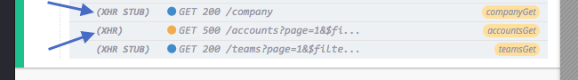

Cypress also logs whether the XHR was stubbed or not to the console when you click on the command in the Command Log. It will indicate whether a request was stubbed, which url it matched or that it did not match any routes.

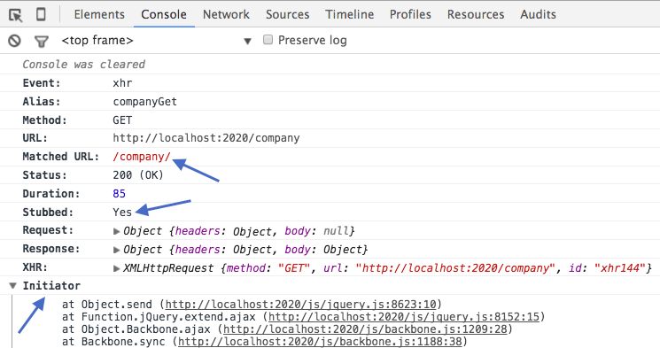

Even the `Initiator` is included, which is a stack trace to what caused the XHR to be sent.

### `cy.route()` cannot be debugged using `cy.request()`

#### `cy.request()` sends requests to actual endpoints, bypassing those defined using `cy.route()`

The intention of `cy.request()` is to be used for checking endpoints on an actual, running server without having to start the front end application.

### Matches

#### Matching origins and non origin URL's

When Cypress matches up an outgoing XHR request to a `cy.route()`, it actually attempts to match it against both the fully qualified URL and then additionally without the URL's origin.

```javascript
cy.route('**/users/*')
```

The following XHRs which were `xhr.open(...)` with these URLs would:

**Match:**

- `/users/1`
- `http://localhost:2020/users/2`
- `https://google.com/users/3`

**Not Match:**

- `/users/4/foo`
- `http://localhost:2020/users/5/foo`

### No matches

#### Requests that don't match any routes

You can force requests that do *not* match a route to return a `404` status and an empty body by passing an option to the `cy.server()` like so:

```javascript
cy.server({ force404: true })
```

You can read more about this here.

## Rules

### Requirements

- `cy.route()` requires being chained off of `cy` .

### Assertions

- `cy.route()` cannot have any assertions chained.

### Timeouts

- `cy.route()` cannot time out.

## Command Log

```javascript
cy.server()
cy.route(/accounts/).as('accountsGet')
cy.route(/company/, 'fixtures:company').as('companyGet')
cy.route(/teams/, 'fixtures:teams').as('teamsGet')
```

Whenever you start a server and add routes, Cypress will display a new Instrument Panel called *Routes*. It will list the routing table in the Instrument Panel, including the `method`, matched URL pattern, `stubbed`, `alias` and number of matched requests:

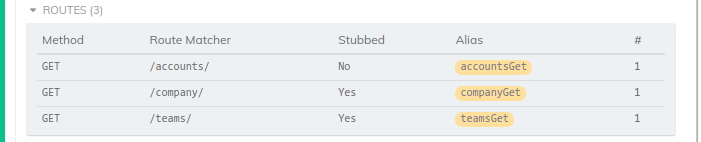

When XHRs are made, Cypress will log them in the Command Log and indicate whether they matched a routing alias:

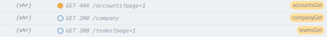

The circular indicator is filled if the request went to the destination server, but unfilled if the request was stubbed with a response.

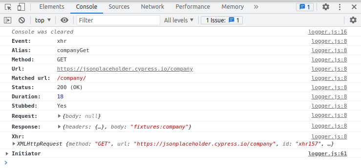

[Read more about request logging in Cypress.](https://docs.cypress.io/guides/guides/network-requests#Command-Log)

## History

| Version | Changes |
| --- | --- |
| [6.0.0](https://docs.cypress.io/guides/references/changelog#6-0-0) | Deprecated `cy.route()` command |

## See also

- [Migrating `cy.route()` to `cy.intercept()`](https://docs.cypress.io/guides/references/migration-guide#Migrating-cy-route-to-cy-intercept)
- `.as()`
- `cy.fixture()`
- `cy.server()`
- `cy.wait()`
- [Guide: Network Requests](https://docs.cypress.io/guides/guides/network-requests)
- [Recipe: Logging in - XHR Web Forms](https://docs.cypress.io/examples/examples/recipes#Logging-In)

© 2017 Cypress.io  
Licensed under the MIT License.  
https://docs.cypress.io/api/commands/route